# pca_hw1

## 3.1. Dimensionality Reduction with PCA:

### Can we reduce the complexity of the design space by using Principal Component Analysis (PCA) to identify key parameters that most influence the S11 response of the antenna?

Yes, the goal of PCA is to reduce the dimensionality of the input design parameters while still capturing the maximum variance, allowing you to focus on the key design features that are most important for predicting the S11 response.

### How much of the total variance in the design parameter space can be explained by the principal components?

The explained variance ratio tells you what proportion of the total variance is captured by each principal component.

|  | Explained Variance Ratio | Cumulative Explained Variance Ratio |
| --- | --- | --- |
| Comp.1 | 0.207153 | 0.207153 |
| Comp.2 | 0.110708 | 0.317862 |
| Comp.3 | 0.100034 | 0.417896 |
| Comp.4 | 0.096072 | 0.513968 |
| Comp.5 | 0.091871 | 0.605839 |
| Comp.6 | 0.088458 | 0.694297 |
| Comp.7 | 0.085659 | 0.779956 |
| Comp.8 | 0.081651 | 0.861607 |
| Comp.9 | 0.073399 | 0.935005 |
| Comp.10 | 0.058303 | 0.993308 |
| Comp.11 | 0.006692 | 1.000000 |

You can see the principal components that explain most of the variance in the input space.

For instance, first principle component (Comp.1) captures around 20% of the variance and allows us to determine the features that are most important for predicting the S11 response.

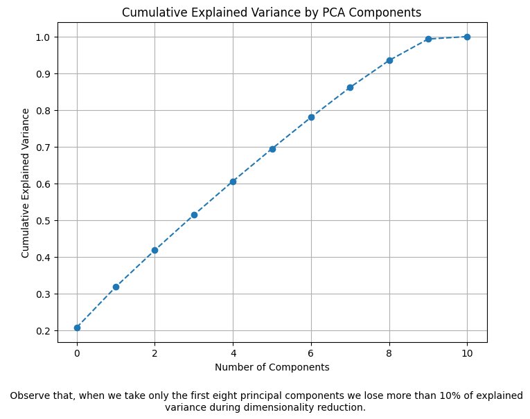

### What insights can we draw from the PCA regarding the relationship between geometry and electromagnetic behavior?

The loadings (coefficients) of the principal components to interpret which of the original design parameters are important for predicting the S11 response:

|  | length of patch | width of patch | height of patch | height of substrate | height of solder resist layer | radius of the probe | c_pad | c_antipad | c_probe | dielectric constant of substrate | dielectric constant of solder resist layer |
| --- | --- | --- | --- | --- | --- | --- | --- | --- | --- | --- | --- |
| Comp.1 | -0.101327 | 0.624178 | 0.071054 | 0.624137 | -0.021049 | 0.025997 | -0.054228 | -0.018720 | 0.039213 | 0.445100 | 0.038422 |
| Comp.2 | 0.315409 | -0.009718 | 0.055716 | 0.018824 | 0.266259 | 0.002815 | -0.265990 | -0.559499 | 0.564753 | -0.012829 | -0.350944 |
| Comp.3 | -0.369645 | 0.040766 | 0.620460 | 0.016441 | 0.086417 | 0.548381 | 0.144827 | 0.088323 | 0.093131 | -0.256167 | -0.255339 |
| Comp.4 | 0.376883 | 0.039631 | 0.392974 | 0.076518 | 0.510652 | -0.454397 | 0.177533 | 0.373926 | -0.151004 | -0.022492 | -0.184975 |
| Comp.5 | 0.409833 | 0.012169 | 0.017701 | 0.028012 | -0.124629 | 0.218986 | 0.580059 | 0.127759 | 0.487544 | 0.012254 | 0.420314 |
| Comp.6 | 0.073314 | -0.032326 | 0.069714 | -0.060565 | 0.459841 | 0.304908 | -0.547579 | 0.172140 | 0.016285 | 0.027772 | 0.591708 |
| Comp.7 | -0.253331 | 0.000413 | -0.490098 | 0.002837 | 0.647199 | 0.212779 | 0.429976 | -0.138146 | -0.102528 | 0.097290 | -0.086813 |
| Comp.8 | 0.454266 | 0.022090 | -0.317943 | 0.059481 | -0.110408 | 0.491478 | -0.174386 | 0.415883 | -0.129279 | 0.053226 | -0.460296 |
| Comp.9 | -0.406238 | -0.040157 | -0.216559 | -0.038186 | 0.040184 | -0.240280 | -0.140321 | 0.548589 | 0.618694 | 0.031927 | -0.145645 |
| Comp.10 | -0.036934 | -0.328516 | 0.243013 | -0.305362 | -0.027430 | 0.080764 | 0.049041 | -0.000574 | 0.000912 | 0.849121 | -0.087887 |
| Comp.11 | -0.036141 | -0.704172 | 0.006071 | 0.708004 | -0.004432 | 0.010532 | -0.010954 | -0.006460 | -0.008289 | -0.018678 | 0.028625 |

For instance, the decomposition of the first component (Comp.1) is given:

Comp.1 = (length of patch × -0.101327) + (width of patch × 0.624178) + (height of patch × 0.071054) + (height of substrate × 0.624137) + (height of solder resist layer × -0.021049) + (radius of the probe × 0.025997) + (c_pad × -0.054228) + (c_antipad × -0.018720) + (c_probe × 0.039213) + (dielectric constant of substrate × 0.445100) + (dielectric constant of solder resist layer × 0.038422)

PCA analysis shows that:

The first principal component 1 is heavily influenced by the width of patch and height of substrate , with a high loading on these parameters. Since principal component 1 covers the biggest variance for the input data the width of patch and height of substrate are key factors affecting overall antenna performance.

Relationships between the features and the real part at a single frequency point:

```
length of patch                              -0.027677
width of patch                                0.830605 # high correlation
height of patch                               0.071386
height of substrate                           0.880056 # high correlation
height of solder resist layer                -0.007944
radius of the probe                          -0.035128
c_pad                                        -0.040812
c_antipad                                    -0.028853
c_probe                                       0.110294
dielectric constant of substrate              0.377078
dielectric constant of solder resist layer    0.033185
100                                           1.000000
Name: 100, dtype: float64
```

Eventhough they look correlated, we do not observe a linear relationship:

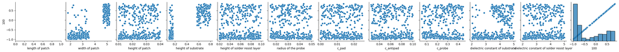

Relationships between the features and the magnitude at a single frequency point:

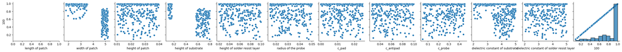

## 3.2. Regression Modeling for S11

### Given that S11 parameters are evaluated at 201 frequency points, predicting them simultaneously through multitarget regression may be computationally intensive and beyond the scope of the content covered so far. Instead, can we simplify the regression task by focusing on predicting S11 at a few key frequency points? For instance, selecting frequencies of interest where the behavior is most critical (e.g., resonance frequencies) can reduce the complexity of the task.

1. The Accuracy Score, Mean Squared Error and execution time for the model where S11 values are evaluated at 201 frequency points are given:

```
0.5594020626180238 # accuracy score
0.019159774874724738 # MSE
23.6s
```

2. The Mean Squared Error and execution time for the model where S11 parameters, real and imaginary parts are evaluated separately at 201 frequency points:

```
0.04225208448301995 #MSE
46.7s
```

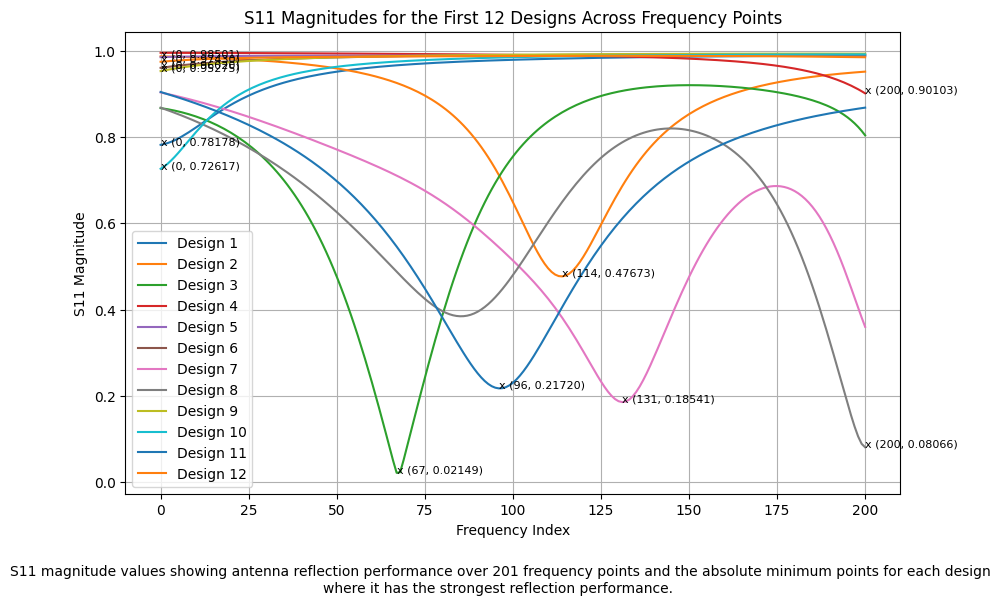

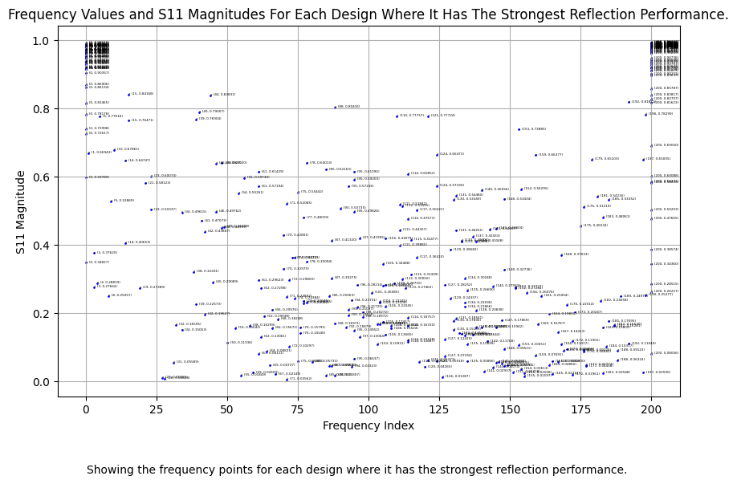

Observe the **Histogram Plot** below. Slecting frequency points 0 and 200 as resonance frequencies, we can significantly reduce the complexity of the regression task. This approach allows you to predict the antenna's performance at the most critical points, rather than trying to model the entire frequency range.

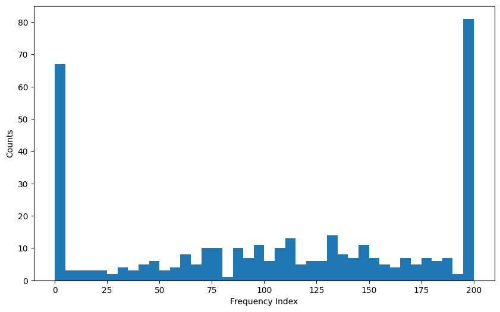

Observe the **Histogram Plot** below that only have frequency reange (10,190). As an additional resonance point, the frequency value 100 can be selected since it has the 3rd most number of designs that have the peak performance at this frequency value.

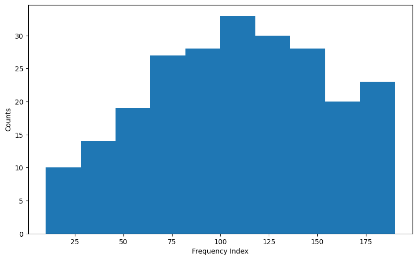

In conclusion, we can reduce the computational complexity and focus on the single frequency points, we get simplier model and fast results but prevents us getting the right results on the resonance points. One may consider more frequency values to get better understanding of the output data.

#### Selecting Resonance Values As The Target

Here we have added the resonance points for the real, imaginary and magnitude of S11 to the data frame along the features.

|  | length of patch | width of patch | height of patch | height of substrate | height of solder resist layer | radius of the probe | c_pad | c_antipad | c_probe | dielectric constant of substrate | dielectric constant of solder resist layer | resonance | resonance_real | resonance_imag |
| --- | --- | --- | --- | --- | --- | --- | --- | --- | --- | --- | --- | --- | --- | --- |
| 0 | 3.202024 | 2.288742 | 0.012514 | 0.139247 | 0.041757 | 0.028566 | 0.000549 | 0.032403 | 0.348140 | 3.735926 | 4.278575 | 0.781778 | -0.976053 | -0.840042 |
| 1 | 2.107848 | 2.895504 | 0.037171 | 0.149492 | 0.056775 | 0.028930 | 0.005536 | 0.053647 | 0.326369 | 4.929862 | 4.876068 | 0.476733 | -0.887572 | -0.544274 |
| 2 | 3.252113 | 4.818411 | 0.025432 | 0.578834 | 0.029972 | 0.030922 | 0.020274 | 0.049845 | 0.446639 | 4.772670 | 4.745106 | 0.021490 | -0.078516 | -0.638543 |
| 3 | 4.161509 | 2.294309 | 0.011058 | 0.117266 | 0.093223 | 0.017604 | 0.001135 | 0.098610 | 0.055665 | 4.102438 | 3.755671 | 0.901033 | -0.856026 | 0.507327 |
| 4 | 4.820912 | 2.948325 | 0.019658 | 0.163503 | 0.094337 | 0.025757 | 0.021725 | 0.072813 | 0.272282 | 2.531031 | 3.047553 | 0.985009 | -0.952876 | 0.249540 |
| ... | ... | ... | ... | ... | ... | ... | ... | ... | ... | ... | ... | ... | ... | ... |
| 380 | 3.950131 | 5.165856 | 0.034389 | 0.770787 | 0.095579 | 0.025591 | 0.011430 | 0.048502 | 0.241219 | 4.099788 | 4.635040 | 0.167674 | 0.159942 | -0.231896 |
| 381 | 2.676373 | 2.826965 | 0.011377 | 0.106795 | 0.055925 | 0.042376 | 0.005102 | 0.060532 | 0.294000 | 4.758303 | 4.205687 | 0.581230 | -0.974088 | -0.708839 |
| 382 | 4.406785 | 1.814310 | 0.011187 | 0.146086 | 0.049041 | 0.040626 | 0.022849 | 0.033737 | 0.225794 | 2.826602 | 4.908306 | 0.985925 | -0.986656 | -0.008603 |
| 383 | 2.540721 | 3.310983 | 0.015000 | 0.135650 | 0.082388 | 0.043490 | 0.011130 | 0.033451 | 0.370502 | 3.303852 | 4.764701 | 0.573305 | -0.906959 | -0.637722 |
| 384 | 2.425315 | 4.998480 | 0.029217 | 0.605634 | 0.028654 | 0.037827 | 0.005896 | 0.033075 | 0.215161 | 4.354493 | 2.676568 | 0.398853 | -0.421003 | -0.510269 |

385 rows × 14 columns

```
# Relationships between the features and the resonance values
```

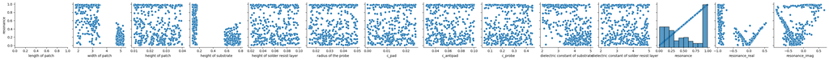

```
# Relationships between the features and the resonance values (real part)
```

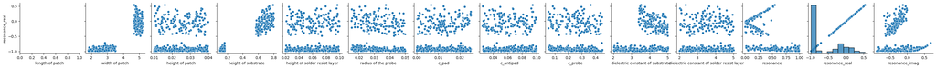

```
# Relationships between the features and the resonance values (imaginary part)
```

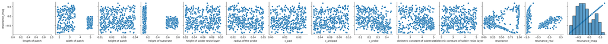

> Applying PCA to The Target Data

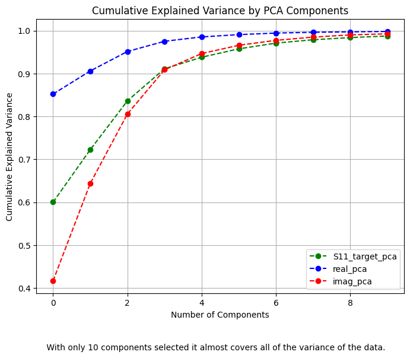

|  | Explained Variance Ratio | Cumulative Explained Variance Ratio |
| --- | --- | --- |
| Comp.1 | 6.001356e-01 | 0.600136 |
| Comp.2 | 1.222789e-01 | 0.722415 |
| Comp.3 | 1.138072e-01 | 0.836222 |
| Comp.4 | 7.500046e-02 | 0.911222 |
| Comp.5 | 2.677452e-02 | 0.937997 |
| ... | ... | ... |
| Comp.197 | 2.113588e-28 | 1.000000 |
| Comp.198 | 2.299940e-29 | 1.000000 |
| Comp.199 | 4.378227e-30 | 1.000000 |
| Comp.200 | 1.357959e-30 | 1.000000 |
| Comp.201 | 1.183559e-31 | 1.000000 |

201 rows × 2 columns

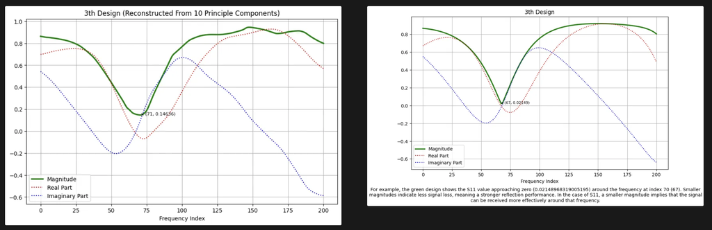

Let us take the first 4 principle components that covers more than 90% of the variance of the target data into the model.

### How effective are linear regression models in predicting the real and imaginary components of S11 at these selected frequency points, based on the geometric parameters of the antenna design?

```
# (real and imaginary parts are evaluated separately at 3 key frequency points)
0.04507268081460516 # MSE (worse)
0.7s

# (S11 is evaluated  at 3 key frequency points)
0.018801862109574585 # MSE (better)
0.4s
```

### What patterns emerge when linear regression is applied to individual frequency points, and do these patterns suggest any broader trends in the design space?

Relationships between the features and the real part at a single frequency point:

```
length of patch                              -0.027677
width of patch                                0.830605 # high correlation
height of patch                               0.071386
height of substrate                           0.880056 # high correlation
height of solder resist layer                -0.007944
radius of the probe                          -0.035128
c_pad                                        -0.040812
c_antipad                                    -0.028853
c_probe                                       0.110294
dielectric constant of substrate              0.377078
dielectric constant of solder resist layer    0.033185
100                                           1.000000
Name: 100, dtype: float64
```

Eventhough they look correlated, we do not observe a linear relationship:

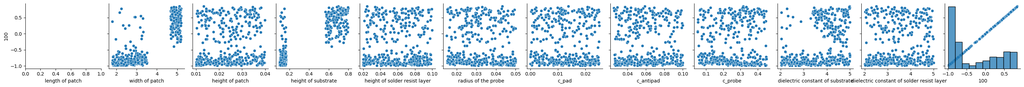

Relationships between the features and the magnitude at a single frequency point:

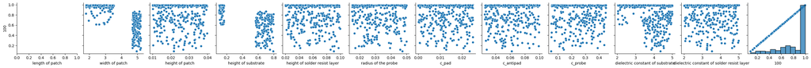

## 3.3. Model Performance and Interpretability:

#### 1. Multitarget Regression

- S11 values are evaluated at 201 frequency points.

```
MSE: 0.019159774874724738
```

- S11 parameters, real and imaginary parts are evaluated separately at 201 frequency points.

```
MSE: 0.0422520844830199
```

#### 2. Multitarget (At Resonance Frequencies) Regression

- S11 values are evaluated at 3 key frequency points (0,100,200).

```
MSE: 0.018801862109574585
```

- S11 parameters, real and imaginary parts are evaluated separately at 3 key frequency points.

```
MSE: 0.04507268081460516
```

#### 3. Multi Target Regression (PCA Applied)

- S11 values are evaluated by 4 principle components.

> Calculate the mean squared error of prediction and the test magnitude (reconstructed from 4 principle components)

```
MSE_5_1 = mean_squared_error(S11_pred_reconstructed, S11_test_reconstructed)
# Prints the mse
print(MSE_5_1)
```

```
0.013517684318910475
```

> Calculate the mean squared error of prediction and the real magnitude

```
MSE_5_2 = mean_squared_error(S11_pred_reconstructed, y_test_201)
# Prints the mse
print(MSE_5_2)
```

```
0.017027761884641314
```

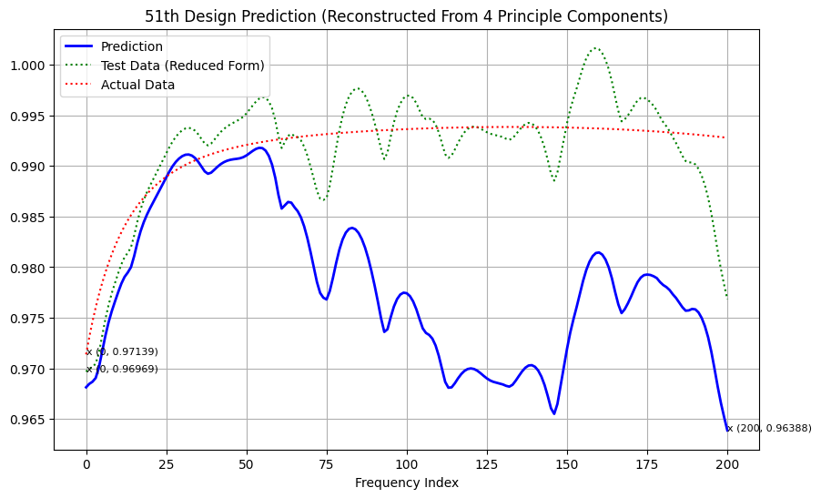

- S11 parameters, real and imaginary parts are evaluated by 4 principle components.

> MSE values for the pca predictions and pca test values for both real and imaginary components.

```
# Calculate the mean squared error
MSE_6 = mean_squared_error(y_test_pca_real, y_pred_pca_real, multioutput='uniform_average')
# Prints the accuracy score
print(MSE_6)
```

```
8.7410756222609
```

```
# Calculate the mean squared error
MSE_7 = mean_squared_error(y_test_pca_imag, y_pred_pca_imag, multioutput='uniform_average')
# Prints the accuracy score
print(MSE_7)
```

```
36.02693734160932
```

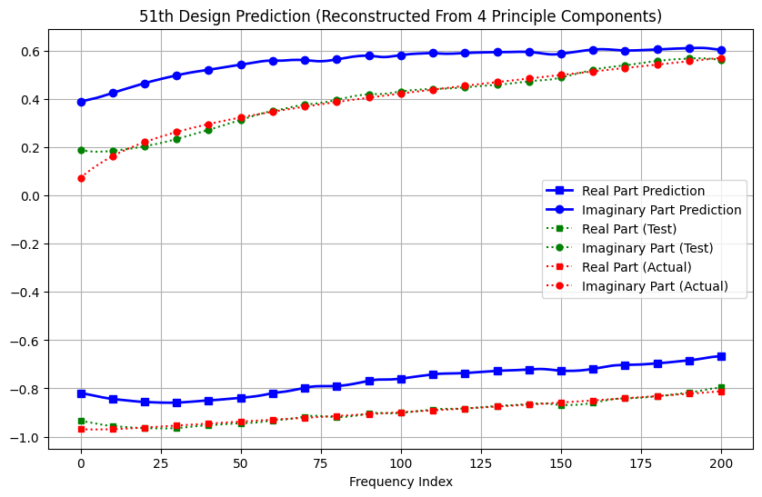

> MSE values for the reconstructe predictions and reconstructed test values and also the actual values for both real and imaginary components.

```
# Score the mse on the test set
MSE_7_1 = mean_squared_error(S11_magnitude_test, S11_magnitude_predict)
# Prints the mse
print(MSE_7_1)
```

```
0.044323588402768226
```

```
# Score the mse on the actual set
MSE_7_2 = mean_squared_error(S11_magnitude, S11_magnitude_predict)
# Prints the mse
print(MSE_7_2)
```

```
0.035406445184256806
```

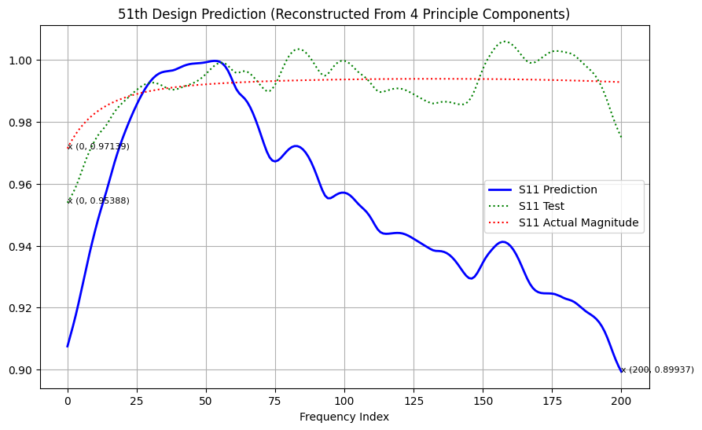